# Neotoma APIs

Nick Hoffman

2025-03-20

# 1 Introduction

This page will introduce the use of Neotoma APIs and describe some situations when they might be preferable to the use of the `neotoma2` R package.

# 2 What is an API?

An API (application programming interface) is a set of rules that allows different computers or computer components to communicate. One set of APIs enable a user’s computer programs to access resources managed by the same computer’s operating system. For example, a program might request memory through an API known as a system call.

The APIs we’re concerned with here are Web APIs. That is, they’re APIs that use Web protocols like HTTP to enable communication between computers through the internet. Web APIs are fundamental to web-based information sharing.

## 2.1 Neotoma APIs

There are a range of Neotoma APIs that can be accessed through this [page](https://api.neotomadb.org/api-docs/). When you call a Web API, it follows the HTTP protocol, which means you issue a request like GET, POST, or PUT, etc., and you receive a response. Let’s see how we can make these API calls in R. We’ll need to download the library `httr`, which has those HTTP calls like `GET()` as well as a `content()` function that helps decode the response we receive.

We want to wrap our call in the `GET()` function, and then decode the contents.

```r
firstAPI = GET("https://api.neotomadb.org/v2.0/data/occurrences?taxonid=35619&limit=10")

print(firstAPI)
```

```
## Response [https://api.neotomadb.org/v2.0/data/occurrences?taxonid=35619&limit=10]
##   Date: 2025-03-20 12:23
##   Status: 200
##   Content-Type: application/json; charset=utf-8
##   Size: 3.99 kB
```

Status: 200 is a good sign; that means the call issued successfully. Now we use `content()` to get the data. The output of `content()`, called insides, has three components: status, data, and message. Most of the time, status will be “success”, and message will be “retrieved all tables,” so we mostly care about the data. But in case you’re ever running into issues and need to debug, it can be helpful to consider what the status and message are.

```r
insides = content(firstAPI)$data

print(insides[1])
```

```
## [[1]]
## [[1]]$occid
## [1] 5314651
##
## [[1]]$sample
## [[1]]$sample$taxonid
## [1] 35619
##
## [[1]]$sample$taxonname
## [1] "Canis spp."
##
## [[1]]$sample$value
## [1] 67
##
## [[1]]$sample$sampleunits
## [1] "NISP"
##
##
## [[1]]$age
## [[1]]$age$age
## NULL
##
## [[1]]$age$ageolder
## [1] 1180
##
## [[1]]$age$ageyounger
## [1] 560
##
##
## [[1]]$site
## [[1]]$site$datasetid
## [1] 37057
##
## [[1]]$site$siteid
## [1] 21575
##
## [[1]]$site$sitename
## [1] "Clachan [NaPi-2]"
##
## [[1]]$site$altitude
## [1] 3
##
## [[1]]$site$location
## [1] "{\"type\":\"Point\",\"crs\":{\"type\":\"name\",\"properties\":{\"name\":\"EPSG:4326\"}},\"coordinates\":[-114.83333,68.16667]}"
##
## [[1]]$site$datasettype
## [1] "vertebrate fauna"
##
## [[1]]$site$database
## [1] "FAUNMAP"
```

We just successfully ran our first API! But the format we received is a little hard to work with…

## 2.2 The JSON format

Web APIs return their responses in JSON (JavaScript Object Notation) format. JSON represents data as arrays of objects in which keys that define a property are assigned values. The value might be a number or string, or it could itself be an object or array of objects. Here’s a snippet of what JSON format looks like:

[{“occid”:[5314651],“sample”:{“taxonid”:[35619],“taxonname”:[“Canis spp.”],“value”:[67],“sampleunits”:[“NISP”]},“age”:{“age”:{},“ageolder”:[1180],“ageyounger”:[560]},“site”:{“datasetid”:[37057],“siteid”:[21575],“sitename”:[“Clachan [NaPi-2]”],“altitude”:[3],“location”:[“{"type":"Point","crs":{"type":"name","properties":{"name":"EPSG:4326"}},"coordinates":[-114.83333,68.16667]}”],“datasettype”:[“vertebrate fauna”],“database”:[“FAUNMAP”]}}

In R, it is natural to represent these JSON arrays as nested lists:

list(occid = 5314651, sample = list(taxonid = 35619, taxonname = “Canis spp.”, value = 67, sampleunits = “NISP”), age = list(age = NULL, ageolder = 1180, ageyounger = 560), site = list(datasetid = 37057, siteid = 21575, sitename = “Clachan [NaPi-2]”, altitude = 3, location = “{"type":"Point","crs":{"type":"name","properties":{"name":"EPSG:4326"}},"coordinates":[-114.83333,68.16667]}”, datasettype = “vertebrate fauna”, database = “FAUNMAP”))

However, it is often easier to visualize an API response as a table rather than a list, which requires some looping. First, we make a matrix with appropriate dimensions. Every row will represent a single observation, and every column will represent a single variable. Then we loop through our nested list and assign each value in the list to an appropriate place in the matrix. Finally, we convert the matrix to a dataframe and name the columns appropriately.

```r
canis_mat = matrix(nrow=length(insides),ncol=12)
for (i in seq(length(insides))) {
  if(!is.null(insides[[i]]$occid)) {
    canis_mat[[i,1]] = insides[[i]]$occid
  }
  for (j in seq(4)) {
    if(!is.null(insides[[i]]$sample[[j]])) {
      canis_mat[[i,(1+j)]] = insides[[i]]$sample[[j]]
    }
  }
   for (k in seq(7)) {
    if(!is.null(insides[[i]]$site[[k]])) {
      canis_mat[[i,(5+k)]] = insides[[i]]$site[[k]]
    }
  }
}

canis_df = as.data.frame(canis_mat)
names(canis_df) = c("occid","taxonid","taxonname","value","units","datasetid","siteid","sitename","altitude","location","datasettype","database")

datatable(canis_df, rownames=FALSE)
```

| occid | taxonid | taxonname | value | units | datasetid | siteid | sitename | altitude | location | datasettype | database |
| --- | --- | --- | --- | --- | --- | --- | --- | --- | --- | --- | --- |
| 5314651 | 35619 | Canis spp. | 67 | NISP | 37057 | 21575 | Clachan [NaPi-2] | 3 | {"type":"Point","crs":{"type":"name","properties":{"name":"EPSG:4326"}},"coordinates":[-114.83333,68.16667]} | vertebrate fauna | FAUNMAP |
| 5314659 | 35619 | Canis spp. | 25 | NISP | 37057 | 21575 | Clachan [NaPi-2] | 3 | {"type":"Point","crs":{"type":"name","properties":{"name":"EPSG:4326"}},"coordinates":[-114.83333,68.16667]} | vertebrate fauna | FAUNMAP |
| 5314670 | 35619 | Canis spp. | 55 | NISP | 37057 | 21575 | Clachan [NaPi-2] | 3 | {"type":"Point","crs":{"type":"name","properties":{"name":"EPSG:4326"}},"coordinates":[-114.83333,68.16667]} | vertebrate fauna | FAUNMAP |
| 5314682 | 35619 | Canis spp. | 104 | NISP | 37057 | 21575 | Clachan [NaPi-2] | 3 | {"type":"Point","crs":{"type":"name","properties":{"name":"EPSG:4326"}},"coordinates":[-114.83333,68.16667]} | vertebrate fauna | FAUNMAP |
| 5318063 | 35619 | Canis spp. | 184 | NISP | 37502 | 21766 | Hamilton [AiHa-5] | 253 | {"type":"Point","crs":{"type":"name","properties":{"name":"EPSG:4326"}},"coordinates":[-80,43.33333]} | vertebrate fauna | FAUNMAP |
| 5442400 | 35619 | Canis spp. | 51 | NISP | 40434 | 23439 | Grassy Bay [GbTn-1] | 15 | {"type":"Point","crs":{"type":"name","properties":{"name":"EPSG:4326"}},"coordinates":[-130.26333,54.31444]} | vertebrate fauna | FAUNMAP |
| 5442450 | 35619 | Canis spp. | 51 | NISP | 40435 | 23439 | Grassy Bay [GbTn-1] | 15 | {"type":"Point","crs":{"type":"name","properties":{"name":"EPSG:4326"}},"coordinates":[-130.26333,54.31444]} | vertebrate fauna | FAUNMAP |
| 5442375 | 35619 | Canis spp. | 1 | present/absent | 40434 | 23439 | Grassy Bay [GbTn-1] | 15 | {"type":"Point","crs":{"type":"name","properties":{"name":"EPSG:4326"}},"coordinates":[-130.26333,54.31444]} | vertebrate fauna | FAUNMAP |
| 5442425 | 35619 | Canis spp. | 1 | present/absent | 40435 | 23439 | Grassy Bay [GbTn-1] | 15 | {"type":"Point","crs":{"type":"name","properties":{"name":"EPSG:4326"}},"coordinates":[-130.26333,54.31444]} | vertebrate fauna | FAUNMAP |

## 2.3 The Neotoma2 R package and the API

You may not have used an API explicitly before, but if you’ve used the `neotoma2` R package, then you’ve already used it implicitly. All `neotoma2` functions at some point require use of the helper function `neotoma2::parseURL()`. This function is somewhat long, but we can use `grep()` to search through it for any mention of an API. When we do we get the following result:

```
baseurl <- switch(use, dev = "https://api-dev.neotomadb.org/v2.0/", ,         neotoma = "https://api.neotomadb.org/v2.0/", local = "http://localhost:3005/v2.0/",
```

`parseURL()` calls the Neotoma API for the `neotoma2` R package. In other words, any `neotoma2` function is ultimately using the Neotoma API to communicate with the database. So why would we ever want to use the APIs directly, rather than mediate through the `neotoma2` R package? There are at least two reasons:

1. It is much faster to use the API directly to download large amounts of data, and
2. Some Neotoma metadata is only available through the API, not the R package.

Let’s examine each of these reasons in order.

# 3 Call time comparison

In order to compare how the call times of the `neotoma2` functions and the Neotoma API scale with the size of the data being handled, we’ll download increasingly large number of sites using the `neotoma2` function `get_sites()` as well as the API call https://api.neotomadb.org/v2.0/data/sites?. `get_sites()` and the API both take as one of their inputs the parameter loc, where we can supply a spatial extent in geoJSON format. We’ll define increasingly large spatial extents as sf objects, and use the R function `system.time()` to measure how long they take. (`system.time()` has three outputs: user, system, and elapsed. We mostly care about elapsed, which is the actual wall time taken for the function to complete. User and system have to do with how the computer operating system allocates resources to run the function.)

```r
lats = c(43, 50, 50, 43)
lons= c(-65, -65, -60, -60)

coordinates = data.frame(lat = lats, lon = lons)

coordinates_sf = coordinates %>%
  st_as_sf(coords = c("lon", "lat"), crs = 4326) %>%
  summarise(geometry = st_combine(geometry)) %>%
  st_cast("POLYGON")

bbox_geojson = sf_geojson(coordinates_sf)

R_getsites_time = system.time(neotoma2::get_sites(loc = bbox_geojson, all_data = TRUE))

api_sites = content(GET(paste0("https://api.neotomadb.org/v2.0/data/sites?loc=",
                               bbox_geojson,
                               "&limit=9999&offset=0")))$data

api_getsites_time = system.time(content(GET(paste0("https://api.neotomadb.org/v2.0/data/sites?loc=",
                                                   bbox_geojson,
                                                   "&limit=99999&offset=0")))$data)

print(length(api_sites))
```

```
## [1] 153
```

The length of the api_sites object printed above is the number of sites we downloaded: around 150.

Let’s print the length of time required to fetch those 150 sites through R:

```r
print(R_getsites_time)
```

```
##    user  system elapsed
##    1.88    0.07    7.30
```

```r
print(api_getsites_time)
```

```
##    user  system elapsed
##    0.03    0.00    0.70
```

Faster than 5 seconds! Let’s repeat this a few times, varying the number of sites downloaded.

```r
lats1 = c(43, 50, 50, 43)
lons1= c(-70, -70, -60, -60)

coordinates1 = data.frame(lat = lats1, lon = lons1)

coordinates1_sf = coordinates1 %>%
  st_as_sf(coords = c("lon", "lat"), crs = 4326) %>%
  summarise(geometry = st_combine(geometry)) %>%
  st_cast("POLYGON")

bbox_geojson1 = sf_geojson(coordinates1_sf)

R_getsites_time1 = system.time(neotoma2::get_sites(loc = bbox_geojson1, all_data = TRUE))

api_sites1 = content(GET(paste0("https://api.neotomadb.org/v2.0/data/sites?loc=",
                                bbox_geojson1,
                                "&limit=9999&offset=0")))$data

api_getsites_time1 = system.time(content(GET(paste0("https://api.neotomadb.org/v2.0/data/sites?loc=",
                                                    bbox_geojson1,
                                                    "&limit=99999&offset=0")))$data)

print(length(api_sites1))
```

```
## [1] 486
```

```r
print(R_getsites_time1)
```

```
##    user  system elapsed
##    6.46    0.15   16.70
```

```r
print(api_getsites_time1)
```

```
##    user  system elapsed
##    0.10    0.00    0.97
```

```r
lats2 = c(33, 50, 50, 33)
lons2 = c(-75, -75, -60, -60)

coordinates2 = data.frame(lat = lats2, lon = lons2)

coordinates2_sf = coordinates2 %>%
  st_as_sf(coords = c("lon", "lat"), crs = 4326) %>%
  summarise(geometry = st_combine(geometry)) %>%
  st_cast("POLYGON")

bbox_geojson2 = sf_geojson(coordinates2_sf)

R_getsites_time2 = system.time(neotoma2::get_sites(loc = bbox_geojson2, all_data = TRUE))

api_sites2 = content(GET(paste0("https://api.neotomadb.org/v2.0/data/sites?loc=",
                                bbox_geojson2,
                                "&limit=9999&offset=0")))$data

api_getsites_time2 = system.time(content(GET(paste0("https://api.neotomadb.org/v2.0/data/sites?loc=",
                                                    bbox_geojson2,
                                                    "&limit=99999&offset=0")))$data)

print(length(api_sites2))
```

```
## [1] 1676
```

```r
print(R_getsites_time2)
```

```
##    user  system elapsed
##   24.15    0.33   64.22
```

```r
print(api_getsites_time2)
```

```
##    user  system elapsed
##    0.32    0.00    1.64
```

The pattern continues below.

```r
lats3 = c(23, 50, 50, 23)
lons3 = c(-80, -80, -60, -60)

coordinates3 = data.frame(lat = lats3, lon = lons3)

coordinates3_sf = coordinates3 %>%
  st_as_sf(coords = c("lon", "lat"), crs = 4326) %>%
  summarise(geometry = st_combine(geometry)) %>%
  st_cast("POLYGON")

bbox_geojson3 = sf_geojson(coordinates3_sf)

R_getsites_time3 = system.time(neotoma2::get_sites(loc = bbox_geojson3, all_data = TRUE))

api_sites3 = content(GET(paste0("https://api.neotomadb.org/v2.0/data/sites?loc=",
                                bbox_geojson3,
                                "&limit=9999&offset=0")))$data

api_getsites_time3 = system.time(content(GET(paste0("https://api.neotomadb.org/v2.0/data/sites?loc=",
                                                    bbox_geojson3,
                                                    "&limit=99999&offset=0")))$data)


print(R_getsites_time3)
```

```
##    user  system elapsed
##   42.83    0.67  126.11
```

```r
print(api_getsites_time3)
```

```
##    user  system elapsed
##    0.66    0.02    2.01
```

```r
print(length(api_sites3))
```

```
## [1] 3236
```

```r
lats4 = c(23, 50, 50, 23)
lons4 = c(-90, -90, -60, -60) # Reordered for a rectangle

coordinates4 = data.frame(lat = lats4, lon = lons4)

coordinates4_sf = coordinates4 %>%
  st_as_sf(coords = c("lon", "lat"), crs = 4326) %>%
  summarise(geometry = st_combine(geometry)) %>%
  st_cast("POLYGON")

bbox_geojson4 = sf_geojson(coordinates4_sf)

R_getsites_time4 = system.time(neotoma2::get_sites(loc = bbox_geojson4, all_data = TRUE))

api_sites4 = content(GET(paste0("https://api.neotomadb.org/v2.0/data/sites?loc=",
                                bbox_geojson4,
                                "&limit=9999&offset=0")))$data

api_getsites_time4 = system.time(content(GET(paste0("https://api.neotomadb.org/v2.0/data/sites?loc=",
                                                    bbox_geojson4,
                                                    "&limit=99999&offset=0")))$data)



print(R_getsites_time4)
```

```
##    user  system elapsed
##   86.95    1.35  318.62
```

```r
print(api_getsites_time4)
```

```
##    user  system elapsed
##    1.26    0.05    4.15
```

```r
print(length(api_sites4))
```

```
## [1] 6283
```

Below you can see how the R package gets slower and slower the greater the number of sites you’re trying to grab, while the API call is always quick. (We added a few points that aren’t displayed above just to fill out the curve without adding too much clutter to the page.) There’s a clear lesson here: the more data you’re dealing with, the bigger the payoff associated with using the APIs directly rather than mediating through the `neotoma2` package.

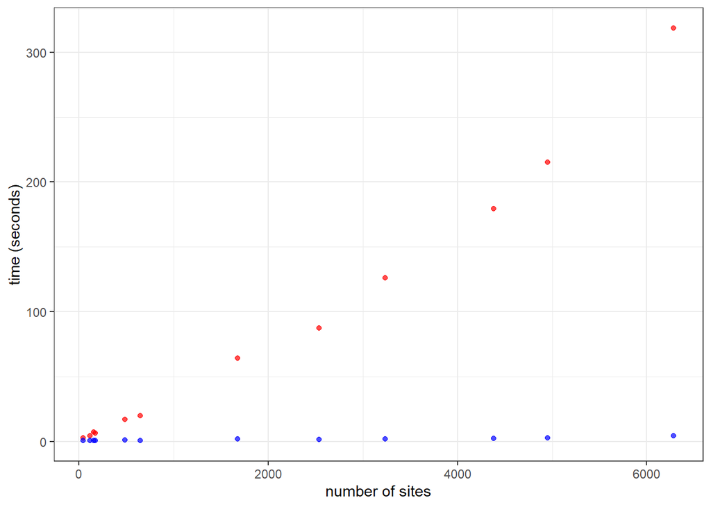

```r
Rtimes = c(R_getsites_time[[3]],R_getsites_time1[[3]],R_getsites_time2[[3]],R_getsites_time3[[3]],
           R_getsites_time4[[3]],R_getsites_timea[[3]],R_getsites_timeb[[3]],
           R_getsites_timec[[3]],R_getsites_timed[[3]],R_getsites_timee[[3]],
           R_getsites_timef[[3]],R_getsites_timeg[[3]])

apitimes = c(api_getsites_time[[3]],api_getsites_time1[[3]],api_getsites_time2[[3]],api_getsites_time3[[3]],
             api_getsites_time4[[3]],api_getsites_timea[[3]],api_getsites_timeb[[3]],api_getsites_timec[[3]],
             api_getsites_timed[[3]],api_getsites_timee[[3]],
             api_getsites_timef[[3]],api_getsites_timeg[[3]])

site_num = c(length(api_sites),length(api_sites1),length(api_sites2),length(api_sites3),length(api_sites4),length(api_sitesa),length(api_sitesb),length(api_sitesc),length(api_sitesd),length(api_sitese),length(api_sitesf),length(api_sitesg))

time_df = data.frame(Rt = Rtimes,api_t = apitimes, sites = site_num)

ggplot(time_df) +
  geom_point(mapping=aes(x=sites,y=Rt),color="red",alpha=0.7) +
  geom_point(mapping=aes(x=sites,y=api_t),color="blue",alpha=0.7) +
  theme_bw() +
  scale_y_continuous(name="time (seconds)") +
  scale_x_continuous(name = "number of sites")
```

# 4 Access More Metadata

The Neotoma database contains extensive metadata that are not all exposed through the R package. (See this [tutorial](https://hoffmanick.github.io/neotomaTutorials/neotomaMetadataWorkflow.html) for even more information about Neotoma metadata.) The API is useful for gathering these metadata. For example, you can see in the image below (from the Neotoma [open schema](https://open.neotomadb.org/dbschema/ndb/tables/sites)), some of the metadata tables linked to samples:

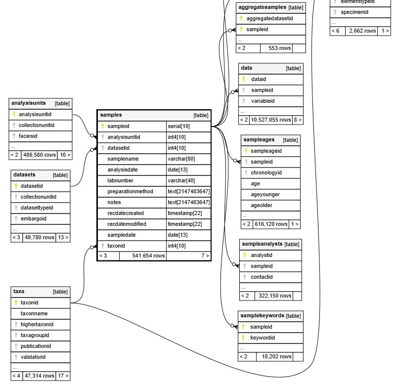

Earlier in this tutorial, I claimed without any evidence that the taxonid which corresponds to *Canis spp.* is 35619. The way I figured that out was through the Neotoma metadata available by API call. I grabbed the taxa table using a particularly versatile API call, “/v2.0/data/dbtables/”, that downloads whichever table name you supply. I turned the returned list into a dataframe for easier analysis, and I grepped through the entire taxa table for any taxa name that included “Canis.”

```r
taxa = content(GET("https://api.neotomadb.org/v2.0/data/dbtables/taxa?count=false&limit=99999&offset=0"))$data

taxa_mat = matrix(nrow=length(taxa),ncol=14)

for (i in seq(length(taxa))) {
  for (j in seq(14)) {
    if(!is.null(taxa[[i]][[j]])) {
      taxa_mat[[i,j]] = taxa[[i]][[j]]
    }
  }
}


taxa_df = as.data.frame(taxa_mat)
names(taxa_df) = c("taxonid","taxoncode","taxonname","author",
                   "valid","highertaxonid","extinct","taxagroupid",
                   "publicationid","validatorid","validatedate",
                   "notes","recdatecreated","recdatemodified")

datatable(taxa_df[grep("Canis",taxa_df$taxonname),],rownames=FALSE)
```

| taxonid | taxoncode | taxonname | author | valid | highertaxonid | extinct | taxagroupid | publicationid | validatorid | validatedate | notes | recdatecreated | recdatemodified |
| --- | --- | --- | --- | --- | --- | --- | --- | --- | --- | --- | --- | --- | --- |
| 5911 | Can.ar | Canis armbrusteri | Gidley, 1913 | TRUE | 6789 | TRUE | MAM | 5068 | 44 | 2012-05-25T00:00:00.000Z |  | 2012-05-25T00:00:00.000Z | 2012-05-25T00:00:00.000Z |
| 5912 | Can.di | Canis dirus | Leidy, 1858 | TRUE | 6789 | TRUE | MAM | 5068 | 44 | 2012-05-25T00:00:00.000Z |  | 2012-05-25T00:00:00.000Z | 2012-05-25T00:00:00.000Z |
| 5913 | Can.ed | Canis edwardii | Gazin, 1942 | TRUE | 6789 | TRUE | MAM | 5068 | 44 | 2012-05-25T00:00:00.000Z |  | 2012-05-25T00:00:00.000Z | 2012-05-25T00:00:00.000Z |
| 5914 | [Can.fm] | Canis familiaris | Linnaeus, 1758 | FALSE |  | FALSE | MAM | 1532 | 44 | 2013-11-14T00:00:00.000Z |  | 2013-01-01T00:00:00.000Z | 2013-11-15T02:38:08.000Z |
| 5915 | Can.la | Canis latrans | Say, 1823 | TRUE | 6789 | FALSE | MAM | 1532 | 44 | 2012-06-12T00:00:00.000Z |  | 2012-06-12T00:00:00.000Z | 2012-06-12T00:00:00.000Z |
| 5916 | Can.le | Canis lepophagus | Johnston, 1938 | TRUE | 6789 | TRUE | MAM | 5068 | 44 | 2012-05-25T00:00:00.000Z |  | 2012-05-25T00:00:00.000Z | 2012-05-25T00:00:00.000Z |
| 5917 | Can.lu | Canis lupus | Linnaeus, 1758 | TRUE | 6789 | FALSE | MAM | 1532 | 44 | 2012-06-12T00:00:00.000Z |  | 2012-06-12T00:00:00.000Z | 2012-06-12T00:00:00.000Z |
| 5918 | Can.pr | Canis priscolatrans | Cope, 1899 | TRUE | 6789 | TRUE | MAM | 1541 | 44 | 2012-06-12T00:00:00.000Z | Tedford et al. (2009) consider this taxon to be a nomen dubium. Specimens originally identified as Canis priscolatrans can be referred to either C. edwardii, C. latrans, or C. armbrusteri. [E.C. Grimm… | 2012-06-12T00:00:00.000Z | 2012-06-12T00:00:00.000Z |
| 5919 | [Can.ru] | Canis rufus | Audubon and Bachman, 1851 | FALSE |  | FALSE | MAM | 1532 | 44 | 2013-03-29T00:00:00.000Z | See extensive comments under Canus lupus in Wozencraft (2005), who considers rufus a hybrid between C. lupus and C. latrans but retains rufus as a subspecies because of uncertain status. [ECG, 2 Aug 2… | 2013-03-29T00:00:00.000Z | 2013-03-29T00:00:00.000Z |
| 5920 | Can.sp | Canis sp. | Linnaeus, 1758 | TRUE | 6789 | FALSE | MAM | 1532 | 44 | 2012-06-12T00:00:00.000Z |  | 2012-06-12T00:00:00.000Z | 2012-06-12T00:00:00.000Z |

[output cut: 48 more lines]

# 5 Conclusion

In this tutorial, we briefly introduced the concept of an API: what they are, how their outputs are formatted, and how the Neotoma APIs relate to the `Neotoma2 R` package. We used a few APIs, and along the way we introduced two compelling reasons to use them: 1) they’re much faster for large data downloads than R, and 2) they provide access to more metadata than the `Neotoma2` R package.

If you would like to provide feedback about this tutorial, please complete this [form](https://docs.google.com/forms/d/e/1FAIpQLSf7aRsbQMa_hj2CKwcpGmF26Huk4MdP9pj5M7zcVF4K2d2zFQ/viewform?usp=sf_link) or reach out to Nick Hoffman at nicholashoffman@ucmerced.edu.